# Health Analytics

Diego Wenceslau

25/01/2021

## Projeto: Podemos Prever o Tempo de Sobrevivência dos Pacientes 1 Ano Após Receberem um Transplante?

[figure not shown]

O objetivo deste projeto é tentar prever o tempo de sobrevivência de um paciente um ano após o transplante de fígado.

Usaremos dados reais disponibilizados publicamente.

Os dados foram extraídos do SRTR Database e modificados para que possa ser executado o script na máquina.

Site oficial dos dados:https://www.srtr.org/about-the-data/the-srtr-database/

**Definindo o diretório de trabalho**

```r
setwd("C:/FCD/Business_Analytics/Cap09")
getwd()
```

```
## [1] "C:/FCD/Business_Analytics/Cap09"
```

**Carregando os dados**

```r
dados <- read.csv("dados/dataset.csv", header = TRUE, na.strings = c(""))
dim(dados)
```

```
## [1] 79100    46
```

**Análise Exploratória, Limpeza, Transformação e Manipulação de Dados (Data Wrangling)** **Visualizando os dados**

**Visualizar as primeiras linhas**

```r
head(dados, 5)
```

```
##   ï..DAYSWAIT_CHRON PSTATUS FINAL_MELD_SCORE PTIME    TX_DATE PX_STAT
## 1                 7       0               39    51 12/24/2018       A
## 2                 5       0               19     6 12/23/2018       A
## 3                10       0               22     6 12/28/2018       A
## 4                 9       0               35    27 12/27/2018       A
## 5                 2       0               35    54 12/20/2018       A
##   PX_STAT_DATE AGE ABO GENDER WGT_KG_TCR HGT_CM_TCR BMI_TCR DIAB INIT_AGE
## 1    2/13/2019  30   O      1      56.24     162.60   21.27    1       30
## 2   12/29/2018  63   A      0      81.92     177.80   25.91    1       63
## 3   01/03/2019  48   B      0      78.93     181.10   24.06    1       48
## 4    1/23/2019  54   O      1      63.50     154.94   26.45    1       54
## 5   02/12/2019  71   O      1      75.75     162.56   28.67    1       71
##   ETHCAT REGION PERM_STATE TX_Year TX_PROCEDUR_TY MED_COND_TRR PREV_TX AGE_DON
## 1      1      2         MD    2018            701            1       N      24
## 2      1      3         GA    2018            701            3       N      34
```

[output cut: 33 more lines]

**Renomeando a primeira coluna**

```r
colnames(dados)[1]<-'DAYSWAIT_CHRON'
```

**Tipos dos dados**

```r
str(dados)
```

```
## 'data.frame':    79100 obs. of  46 variables:
##  $ DAYSWAIT_CHRON      : int  7 5 10 9 2 6 4 9 1 11 ...
##  $ PSTATUS             : int  0 0 0 0 0 0 0 1 1 0 ...
##  $ FINAL_MELD_SCORE    : int  39 19 22 35 35 19 35 14 36 23 ...
##  $ PTIME               : int  51 6 6 27 54 10 51 0 3 6 ...
##  $ TX_DATE             : Factor w/ 6139 levels "01/01/2003","01/01/2004",..: 3554 3537 3622 3605 3486 3554 3520 3622 3486 3656 ...
##  $ PX_STAT             : Factor w/ 2 levels "A","D": 1 1 1 1 1 1 1 2 2 1 ...
##  $ PX_STAT_DATE        : Factor w/ 5774 levels ".","01/01/2003",..: 3502 3455 51 1899 391 51 374 3440 3360 83 ...
##  $ AGE                 : int  30 63 48 54 71 62 62 56 28 66 ...
##  $ ABO                 : Factor w/ 8 levels "A","A1","A1B",..: 8 1 7 8 8 8 8 1 7 1 ...
##  $ GENDER              : int  1 0 0 1 1 1 1 0 1 0 ...
##  $ WGT_KG_TCR          : num  56.2 81.9 78.9 63.5 75.8 ...
##  $ HGT_CM_TCR          : num  163 178 181 155 163 ...
##  $ BMI_TCR             : num  21.3 25.9 24.1 26.4 28.7 ...
##  $ DIAB                : int  1 1 1 1 1 3 1 1 1 1 ...
```

[output cut: 32 more lines]

**Explorando os dados das variáveis numéricas**

**A maioria dos pacientes, tem em torno de 60 anos de idade**

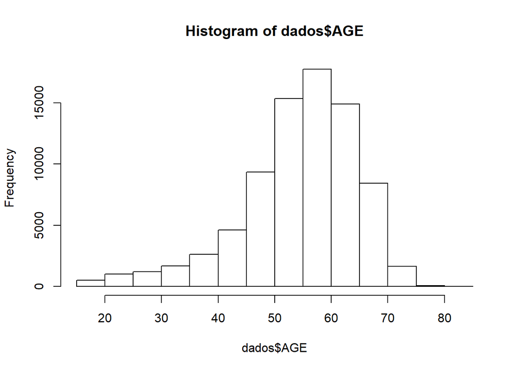

```r
hist(dados$AGE)
```

**A idade dos doadores de fígado, é bem variada, com quantidade maior de doadores, começando um pouco antes dos 20 anos de idade.**

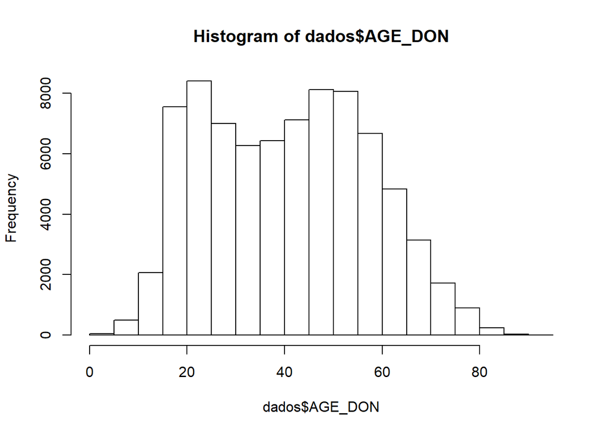

```r
hist(dados$AGE_DON)
```

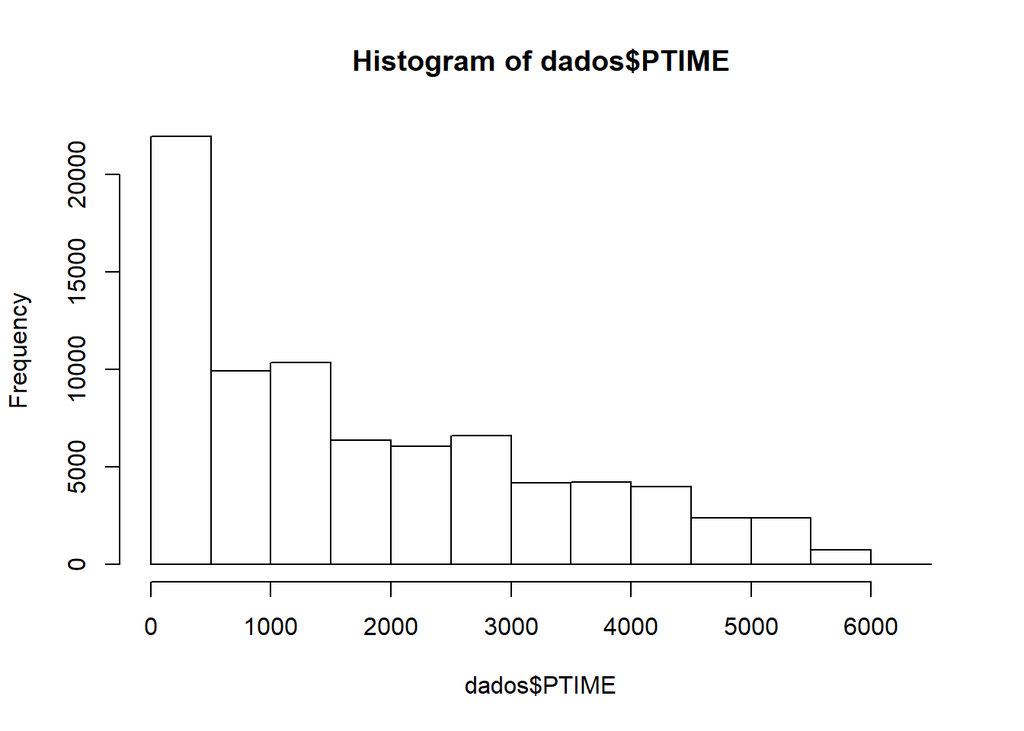

```r
hist(dados$PTIME)
```

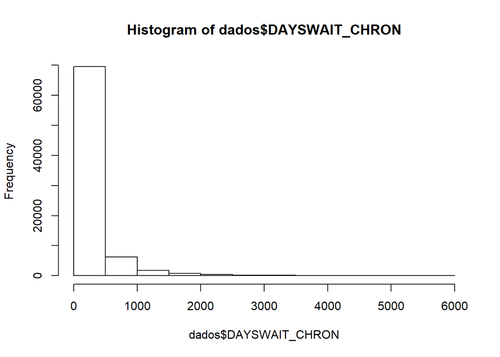

```r
hist(dados$DAYSWAIT_CHRON)
```

**Pontuação do score da doença hepática que é qualquer condição que danifica o fígado e impede seu bom funcionamento.**

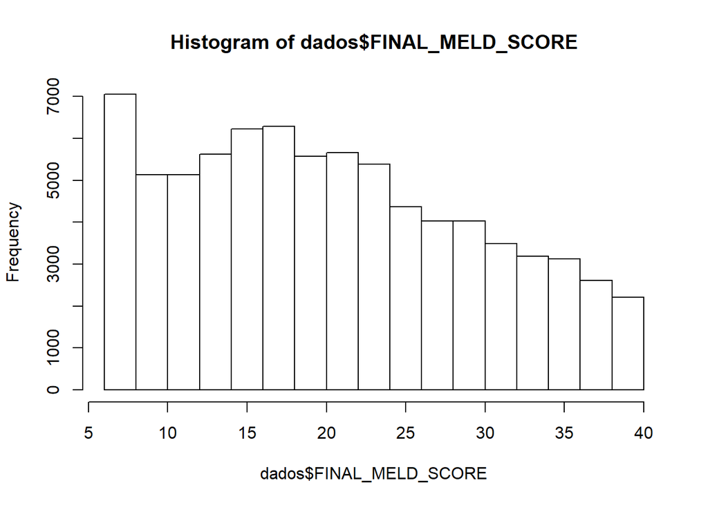

```r
hist(dados$FINAL_MELD_SCORE)
```

**Explorando os dados das variáveis categóricas**

```r
dados$DIAB <- as.factor(dados$DIAB)
table(dados$DIAB)
```

```
##
##     1     2     3     4     5   998
## 57017  1520 16476   309  2939   828
```

**A quantidade mostra mais pacientes sobreviveram ao transplante.** **0 -> não veio a óbito** **1 -> veio a óbito**

```r
dados$PSTATUS <- as.factor(dados$PSTATUS)
table(dados$PSTATUS)
```

```
##
##     0     1
## 55634 23466
```

**Quantidade de paciente que recebe transplante.** **0 -> Masculino** **1 -> Feminino**

```r
dados$GENDER <- as.factor(dados$GENDER)
table(dados$GENDER)
```

```
##
##     0     1
## 53312 25788
```

**Quantidade de doadores.** **0 -> Masculino** **1 -> Feminino**

```r
dados$GENDER_DON <- as.factor(dados$GENDER_DON)
table(dados$GENDER_DON)
```

```
##
##     0     1
## 47310 31790
```

**Regiõess.**

```r
dados$REGION <- as.factor(dados$REGION)
table(dados$REGION)
```

```
##
##     1     2     3     4     5     6     7     8     9    10    11
##  2802  9435 14070  7436  9962  2505  6503  5458  4745  7656  8528
```

**Se tem tumor maligimo**

```r
dados$MALIG <- as.factor(dados$MALIG)
table(dados$MALIG)
```

```
##
##     N     U     Y
## 42828 21290 14982
```

```r
dados$HIST_CANCER_DON <- as.factor(dados$HIST_CANCER_DON)
table(dados$HIST_CANCER_DON)
```

```
##
##     N     U     Y
## 76040   398  2660
```